# Jobs Paying a Living Wage

Author

Kevin Werner, Kassandra Martincheck, and Aaron R. Williams

Abstract

This document combines Bureau of Labor Statistics Quarterly Census of Employment and Wages (QCEW) data and Living Wage Institute data to calculate how much of the cost of living the average pay of jobs covers.

## Load Software

```r
library(tidyverse)
library(here)
library(janitor)
library(readxl)

# increase the download timeout in case the internet is slow
options(timeout = 120)

theme_set(theme_minimal())
```

## QCEW data

We first download data from the BLS for the [Quarterly Census of Employment and Wages (QCEW)](https://www.bls.gov/cew/downloadable-data-files.htm). The file layout is available [here](https://www.bls.gov/cew/about-data/downloadable-file-layouts/high-level/home.htm). Data codes are available [here](https://www.bls.gov/cew/about-data/documentation-guide.htm).

### Download QCEW data

```r
#' This downloads the QCEW data from the BLS website and saves it in the data
#' directory
#'
#' @param bls_path The filepath of the .xlsx document with QCEW data from the BLS
#' @param year The last two digits of the year
#'
#' @returns
#'
download_qcew <- function(bls_path, year) {

  temp_file_path <- tempfile()
  temp_dir_path <- tempdir()
  output_file <- here("02_jobs-paying-living-wages", "data", "qcew", str_glue("allhlcn{year}.xlsx"))

  if (file.exists(output_file)) {

    return(str_glue("QCEW for {year} already downloaded."))

  }

  download.file(
    url = bls_path,
    destfile = temp_file_path
  )

  unzip(temp_file_path, exdir = temp_dir_path)

  file.rename(
    paste0(temp_dir_path, "/allhlcn", year, ".xlsx"),
    output_file
  )

  unlink(temp_file_path)
  unlink(temp_dir_path)

}

qcew_urls <- tribble(
  ~url, ~year,
  "https://data.bls.gov/cew/data/files/2014/xls/2014_all_county_high_level.zip", 14,
  "https://data.bls.gov/cew/data/files/2015/xls/2015_all_county_high_level.zip", 15,
  "https://data.bls.gov/cew/data/files/2016/xls/2016_all_county_high_level.zip", 16,
  "https://data.bls.gov/cew/data/files/2017/xls/2017_all_county_high_level.zip", 17,
  "https://data.bls.gov/cew/data/files/2018/xls/2018_all_county_high_level.zip", 18,
  "https://data.bls.gov/cew/data/files/2019/xls/2019_all_county_high_level.zip", 19,
  "https://data.bls.gov/cew/data/files/2020/xls/2020_all_county_high_level.zip", 20,
  "https://data.bls.gov/cew/data/files/2021/xls/2021_all_county_high_level.zip", 21,
  "https://data.bls.gov/cew/data/files/2022/xls/2022_all_county_high_level.zip", 22,
  "https://data.bls.gov/cew/data/files/2023/xls/2023_all_county_high_level.zip", 23,
  "https://data.bls.gov/cew/data/files/2024/xls/2024_all_county_high_level.zip", 24
)

walk2(
  .x = qcew_urls$url,
  .y = qcew_urls$year,
  .f = download_qcew
)
```

### Load and Clean QCEW Data

We clean the QCEW data so it only includes data for total covered employment at the county level. We convert missing values, represented at zeros, to `NA`.

```r
qcew_files <- list.files(here("02_jobs-paying-living-wages", "data", "qcew"))

#' Load and clean the QCEW .xlsx files
#'
#' @param file The file name
#'
#' @returns Cleaned QCEW data
#'
load_qcew <- function(file) {

  # pull year from the file name
  year <- paste0("20", str_remove_all(file, "[a-z]|[\\.]")) |>
    as.numeric()

  read_excel(here("02_jobs-paying-living-wages", "data", "qcew", file)) |>
    clean_names() |>
    filter(area_type == "County", ownership == "Total Covered") |>
    select(
      state = st,
      county = cnty,
      annual_average_weekly_wage,
      annual_average_establishment_count
    ) |>
    mutate(
      state = str_pad(state, width = 2, side = "left", pad = "0"),
      county = str_pad(county, width = 3, side = "left", pad = "0"),
      geo_id = paste0(state, county),
      year = year
    ) |>
    mutate(
      annual_average_weekly_wage = na_if(annual_average_weekly_wage, 0),
      annual_average_establishment_count = na_if(annual_average_establishment_count, 0)
    )

}

qcew <- map_dfr(.x = qcew_files, .f = load_qcew)
```

The QCEW includes county 999, which is for “Unknown Or Undefined” area. We drop these.

```r
qcew <- qcew |>
  filter(county != "999")
```

### QCEW Data Checks

We explore the QCEW data to evaluate the quality of the data.

```r
summary(qcew$annual_average_weekly_wage)
```

```
   Min. 1st Qu.  Median    Mean 3rd Qu.    Max.    NA's
  382.0   704.0   812.0   852.4   951.0  3789.0       3
```

We look at counties with large changes in the rank of `annual_average_weekly_wage`.

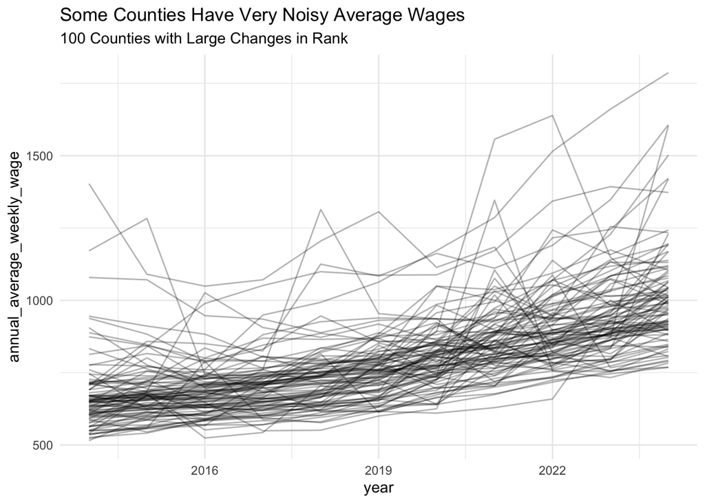

```r
# high variance
big_wage_changes <- qcew |>
  group_by(year) |>
  mutate(rank = rank(annual_average_weekly_wage, ties.method = "average")) |>
  group_by(state, county) |>
  mutate(rank_change = rank - lag(rank)) |>
  arrange(desc(abs(rank_change))) |>
  ungroup()

big_wage_changes_id <- big_wage_changes |>
  slice_max(rank_change, n = 100) |>
  pull(geo_id)

qcew |>
  filter(geo_id %in% big_wage_changes_id) |>
  mutate(geo_id = paste0(state, county)) |>
  ggplot(aes(year, annual_average_weekly_wage, group = geo_id)) +
  geom_line(alpha = 0.3) +
  labs(
    title = "Some Counties Have Very Noisy Average Wages",
    subtitle = "100 Counties with Large Changes in Rank"
  )
```

```r
# annual_average_establishment_count
summary(qcew$annual_average_establishment_count)
```

```
   Min. 1st Qu.  Median    Mean 3rd Qu.    Max.
     10     285     648    3084    1772  572385
```

We look at counties with large changes in the rank of `annual_average_establishment_count`.

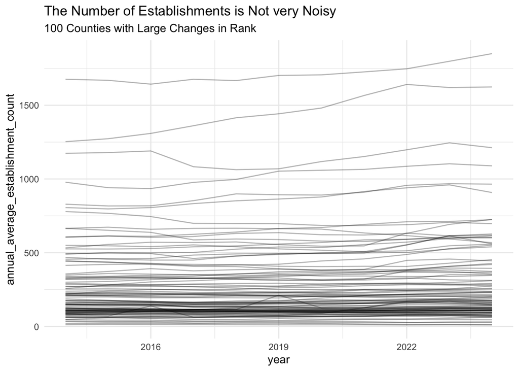

```r
# high variance
big_establishment_changes <- qcew |>
  group_by(year) |>
  mutate(rank = rank(annual_average_establishment_count, ties.method = "average")) |>
  group_by(state, county) |>
  mutate(rank_change = rank - lag(rank)) |>
  arrange(desc(abs(rank_change))) |>
  ungroup()

big_establishment_changes_id <- big_wage_changes |>
  slice_max(rank_change, n = 100) |>
  pull(geo_id)

qcew |>
  filter(geo_id %in% big_establishment_changes_id) |>
  mutate(geo_id = paste0(state, county)) |>
  ggplot(aes(year, annual_average_establishment_count, group = geo_id)) +
  geom_line(alpha = 0.3) +
  labs(
    title = "The Number of Establishments is Not very Noisy",
    subtitle = "100 Counties with Large Changes in Rank"
  )
```

We expect every county to be included 11 times. Some counties are included fewer times and these are the usual suspects in Alaska, Connecticut, and South Dakota.

```r
count(qcew, state, county) |>
  filter(n != 11) |>
  print(n  = Inf)
```

```
# A tibble: 24 × 3
   state county     n
   <chr> <chr>  <int>
 1 02    063        5
 2 02    066        5
 3 02    158       10
 4 02    261        6
 5 02    270        2
 6 09    001       10
 7 09    003       10
 8 09    005       10
 9 09    007       10
10 09    009       10
11 09    011       10
12 09    013       10
13 09    015       10
14 09    110        1
15 09    120        1
16 09    130        1
17 09    140        1
18 09    150        1
19 09    160        1
20 09    170        1
21 09    180        1
22 09    190        1
23 46    102       10
24 46    113        2
```

## Load MIT Data

Next we process data from the Living Wage Institute. We can’t publicly share this data. All files are available on Box.

We use several different years of Living Wage Institute data. Since we don’t have the underlying data for all years from 2014 to the present, we inflation adjust the years we have to fill in the gaps.

```r
living_wage_2018 <- read_csv(
  here("02_jobs-paying-living-wages", "data", "living-wage", "mit-living-wage.csv")
)

living_wage_2018 <- living_wage_2018 |>
  filter(adults == "1 Adult", children == "2 Children") |>
  distinct() |>
  # convert 2018 dollars into 2019 dollars using the CPI values from inflation_adjust()
  mutate(wage =  wage * 255.657 / 251.107)

living_wage_2014_2018 <- bind_rows(
  living_wage_2018 |>
    mutate(year = 2014),
    living_wage_2018 |>
    mutate(year = 2015),
    living_wage_2018 |>
    mutate(year = 2016),
    living_wage_2018 |>
    mutate(year = 2017),
  living_wage_2018
)
```

```r
living_wage_2022 <- read_csv(
  here("02_jobs-paying-living-wages", "data", "living-wage", "mit-living-wage-2022.csv")
)

living_wage_2022 <- living_wage_2022 |>
  filter(adults == "1 Adult", children == "2 Children") |>
  distinct()

living_wage_2019_2022 <- bind_rows(
  living_wage_2022 |>
    mutate(year = 2019),
  living_wage_2022 |>
    mutate(year = 2020),
  living_wage_2022,
  living_wage_2022 |>
    mutate(year = 2022)
)
```

```r
living_wage_2023 <- read_csv(
  here("02_jobs-paying-living-wages", "data", "living-wage", "mit-living-wage-2023.csv")
) |>
  select(
    year,
    state = state_fips,
    county = county_fips,
    hourly_living_wage,
    wage = hourly_living_wage,
    wage_adj = hourly_living_wage
  ) |>
  mutate(county = str_sub(county, start = 3, end = 5))
```

```r
living_wage_2024 <- read_excel(
  here("02_jobs-paying-living-wages", "data", "living-wage", "LWI-BenchmarkSeries-County-Urban Institute-2025-10-10.xlsx")
) |>
  select(
    year,
    state = state_fips,
    county = county_fips,
    hourly_living_wage,
    wage = hourly_living_wage,
    wage_adj = hourly_living_wage
  ) |>
  mutate(year = 2024) |>
  mutate(county = str_sub(county, start = 3, end = 5))
```

### Inflation Adjust

We use the [CPI-U](https://www.bls.gov/regions/mid-atlantic/data/consumerpriceindexannualandsemiannual_table.htm) to inflation adjust the living wages values to different years. In all cases, the goal is to end up with nominal dollars.

```r
#' Inflation adjust LWI data
#'
#' @param data The Living Wage Institute data in a tibble
#' @param qcew_year The represented by the LWI data
#'
#' Values in earlier years should decrease (e.g., 2014 should be lower than
#' 2018) because the resulting data are in nominal dollars.
#'
inflation_adjust <- function(data, qcew_year) {

  # CPI-U annual averages from BLS (Consumer Price Index for All Urban Consumers)
  # Source: https://www.bls.gov/regions/mid-atlantic/data/consumerpriceindexannualandsemiannual_table.htm
  cpi_u <- c(
    "2014" = 236.736,
    "2015" = 237.017,
    "2016" = 240.007,
    "2017" = 245.120,
    "2018" = 251.107,
    "2019" = 255.657,
    "2020" = 258.811,
    "2021" = 270.970,
    "2022" = 292.655,
    "2023" = 304.702,
    "2024" = 313.689
  )

  data |>
    mutate(wage_adj = wage * cpi_u[as.character(year)] / cpi_u[as.character(qcew_year)])


}

living_wage_2014_2018 <- inflation_adjust(data = living_wage_2014_2018, qcew_year = 2018)

living_wage_2019_2022 <- inflation_adjust(data = living_wage_2019_2022, qcew_year = 2022)
```

Combine all of the data into a series of living wage metrics.

```r
living_wage <- bind_rows(
  living_wage_2014_2018,
  living_wage_2019_2022,
  living_wage_2023,
  living_wage_2024
) |>
  mutate(geo_id = paste0(state, county))

living_wage <- living_wage |>
  select(-adults, -children)
```

### Living Wage Data Checks

Perform some quality checks on the LWI data.

```r
summary(living_wage$wage_adj)
```

```
   Min. 1st Qu.  Median    Mean 3rd Qu.    Max.
  22.61   27.79   32.28   33.55   37.61   89.18
```

Inflation adjusting maintains the sort order of the data, which is different than the reported data. There are also big gaps on the seams between data sources.

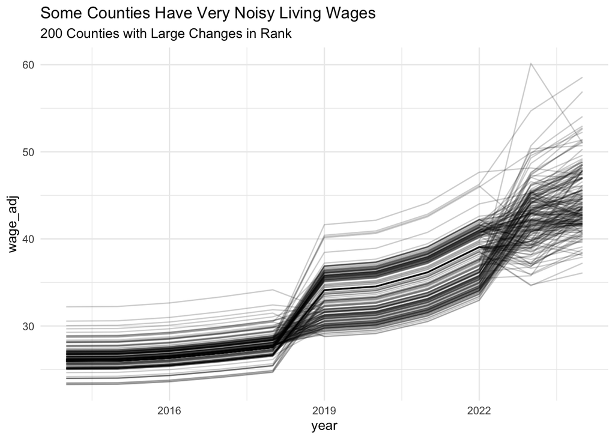

```r
big_lw_changes <- living_wage |>
  group_by(year) |>
  mutate(rank = rank(wage_adj, ties.method = "average")) |>
  group_by(state, county) |>
  mutate(rank_change = rank - lag(rank)) |>
  arrange(desc(abs(rank_change))) |>
  ungroup()

big_lw_changes_id <- big_lw_changes |>
  slice_max(rank_change, n = 200) |>
  pull(geo_id)

living_wage |>
  filter(geo_id %in% big_lw_changes_id) |>
  ggplot(aes(year, wage_adj, group = geo_id)) +
  geom_line(alpha = 0.2) +
  labs(
    title = "Some Counties Have Very Noisy Living Wages",
    subtitle = "200 Counties with Large Changes in Rank"
  )
```

## Join Data

Both data sets approximately have the correct number of observations per year.

```r
count(qcew, year)
```

```
# A tibble: 11 × 2
    year     n
   <dbl> <int>
 1  2014  3141
 2  2015  3143
 3  2016  3141
 4  2017  3141
 5  2018  3141
 6  2019  3141
 7  2020  3142
 8  2021  3142
 9  2022  3142
10  2023  3142
11  2024  3143
```

```r
count(living_wage, year)
```

```
# A tibble: 11 × 2
    year     n
   <dbl> <int>
 1  2014  3142
 2  2015  3142
 3  2016  3142
 4  2017  3142
 5  2018  3142
 6  2019  3142
 7  2020  3142
 8  2021  3142
 9  2022  3142
10  2023  3143
11  2024  3143
```

There are a few mismatches between counties in the expected places like Alaska and Connecticut.

```r
qcew |>
  anti_join(living_wage, by = c("year", "state", "county"))
```

```
# A tibble: 19 × 6
   state county annual_average_weekly_wage annual_average_establi…¹ geo_id  year
   <chr> <chr>                       <dbl>                    <dbl> <chr>  <dbl>
 1 02    270                           501                      144 02270   2014
 2 46    113                           714                      122 46113   2014
 3 02    270                           504                       71 02270   2015
 4 46    113                           701                       59 46113   2015
 5 02    063                          1272                      413 02063   2020
 6 02    066                          1097                      145 02066   2020
 7 02    063                          1314                      413 02063   2021
 8 02    066                          1007                      154 02066   2021
 9 02    063                          1306                      411 02063   2022
10 02    066                          1009                      157 02066   2022
11 09    110                          1594                    36617 09110   2024
12 09    120                          1441                    10884 09120   2024
13 09    130                          1353                     6800 09130   2024
14 09    140                          1377                    13526 09140   2024
15 09    150                          1120                     2962 09150   2024
16 09    160                          1237                     4670 09160   2024
17 09    170                          1452                    20772 09170   2024
18 09    180                          1356                     9101 09180   2024
19 09    190                          2482                    33324 09190   2024
# ℹ abbreviated name: ¹annual_average_establishment_count
```

```r
anti_join(living_wage, qcew, by = c("year", "state", "county"))
```

```
# A tibble: 24 × 6
    year state county  wage wage_adj geo_id
   <dbl> <chr> <chr>  <dbl>    <dbl> <chr>
 1  2014 02    158     31.5     29.7 02158
 2  2014 15    005     30.5     28.8 15005
 3  2014 46    102     26.9     25.3 46102
 4  2015 15    005     30.5     28.8 15005
 5  2016 15    005     30.5     29.2 15005
 6  2017 15    005     30.5     29.8 15005
 7  2018 15    005     30.5     30.5 15005
 8  2019 15    005     45.5     39.7 15005
 9  2020 02    261     40.8     36.1 02261
10  2020 15    005     45.5     40.2 15005
# ℹ 14 more rows
```

Finally, we combine the QCEW and Living Wage Institute data. We use an `inner_join()` because we only want to keep observations common to both data sets. Later, we will fill in missing values using the target geographies file.

```r
combined_data <- inner_join(qcew, living_wage, by = c("year", "state", "county"))

count(combined_data, year)
```

```
# A tibble: 11 × 2
    year     n
   <dbl> <int>
 1  2014  3139
 2  2015  3141
 3  2016  3141
 4  2017  3141
 5  2018  3141
 6  2019  3141
 7  2020  3140
 8  2021  3140
 9  2022  3140
10  2023  3142
11  2024  3134
```

## Calculate Living Wage Ratio

We convert the adjusted hourly wage into a weekly wage and then compare with the weekly QCEW wage data.

```r
combined_data <- combined_data |>
  mutate(weekly_living_wage = wage_adj * 40) |>
  mutate(ratio_living_wage = annual_average_weekly_wage / weekly_living_wage)
```

## Data Quality

Greg and Kevin established the original data quality flag based on the number of establishments in the geography.

- > = 30 is 1
- <30 is 3

```r
combined_data <- combined_data |>
  mutate(
    ratio_living_wage_quality = if_else(
      condition = annual_average_establishment_count < 30,
      true = 3,
      false = 1
    )
  )
```

## Join to Target Geography File

We join our calculated data to the target geographies file for counties.

```r
target_counties <- read_csv(here("geographic-crosswalks", "data", "county-populations.csv")) |>
  select(year, state, county)

final_data <- left_join(
  target_counties,
  combined_data,
  by = c("year", "state", "county")
)

anti_join(
  combined_data,
  target_counties,
  by = c("year", "state", "county")
)
```

```
# A tibble: 16 × 12
   state county annual_average_weekly_wage annual_average_estab…¹ geo_id.x  year
   <chr> <chr>                       <dbl>                  <dbl> <chr>    <dbl>
 1 09    001                          2015                  41653 09001     2022
 2 09    003                          1508                  32352 09003     2022
 3 09    005                          1113                   6909 09005     2022
 4 09    007                          1260                   6013 09007     2022
 5 09    009                          1312                  27406 09009     2022
 6 09    011                          1308                   8329 09011     2022
 7 09    013                          1137                   3576 09013     2022
 8 09    015                          1027                   3321 09015     2022
 9 09    001                          2074                  43233 09001     2023
10 09    003                          1553                  33488 09003     2023
11 09    005                          1160                   7087 09005     2023
12 09    007                          1306                   6213 09007     2023
13 09    009                          1354                  28213 09009     2023
14 09    011                          1346                   8559 09011     2023
15 09    013                          1175                   3684 09013     2023
16 09    015                          1078                   3436 09015     2023
# ℹ abbreviated name: ¹annual_average_establishment_count
# ℹ 6 more variables: wage <dbl>, wage_adj <dbl>, geo_id.y <chr>,
#   weekly_living_wage <dbl>, ratio_living_wage <dbl>,
#   ratio_living_wage_quality <dbl>
```

```r
map_dbl(final_data, ~sum(is.na(.x)))
```

```
                              year                              state
                                 0                                  0
                            county         annual_average_weekly_wage
                                 0                                 49
annual_average_establishment_count                           geo_id.x
                                46                                 46
                              wage                           wage_adj
                                46                                 46
                          geo_id.y                 weekly_living_wage
                                46                                 46
                 ratio_living_wage          ratio_living_wage_quality
                                49                                 46
```

## Finalize File

```r
final_data <- final_data |>
  select(year, state, county, ratio_living_wage, ratio_living_wage_quality)

write_csv(
  final_data,
  file = here("02_jobs-paying-living-wages", "data", "final", "living_wage_county_all_longitudinal.csv")
)
```

## Evaluation

```r
source(here::here("functions", "testing", "evaluate_final_data.R"))
```

## Run Evaluation Test

Enter the information into the `evaluate_final_data` function.

Count level data all.

```r
evaluate_final_data(
  exp_form_path = "10a_final-evaluation/evaluation_form_living_wage_overall_county.csv",
  data = final_data,
  geography = "county",
  subgroups = FALSE,
  confidence_intervals = FALSE
)
```

```
[1] "This data passes all tests!"
```